# CCFRP Survey Basic Figures

E. Johnston, E. Brauer, G. Waltz, B. Ruttenberg, D. Wendt

December 2021

## Section 2) Marine Protected Areas

### 9 & 11

**Before and After** volunteering with CCFRP, what was your general opinion of the creation of MPAs in California? My general opinion or MPA creation was …

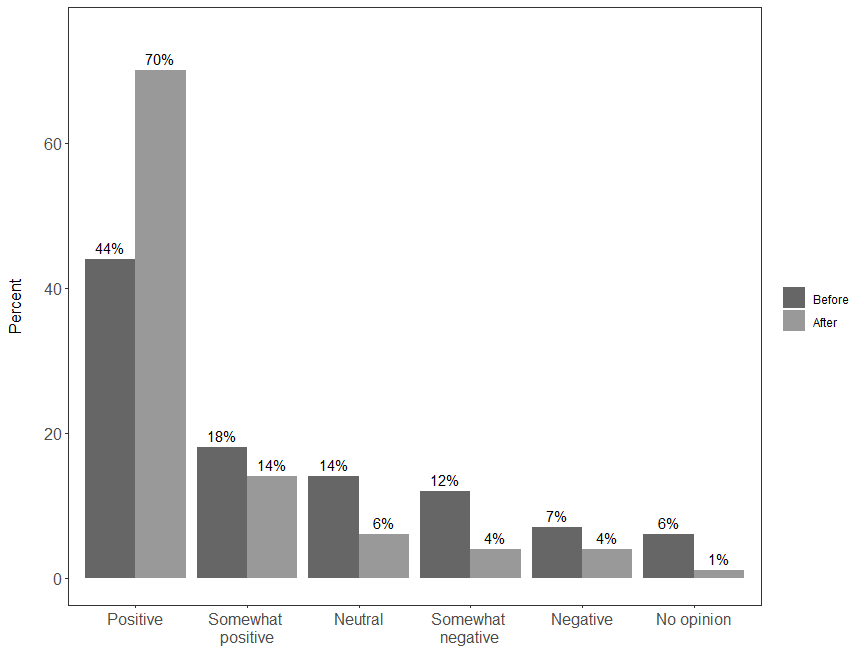

Figure 1. The percentage distribution of respondents’ opinions about the creation of MPAs in California before (dark shaded bars, n = 229) and after volunteering with the California Collaborative Fisheries Research Program (light shaded bars, n = 228).Involvement with CCFRP generally corresponded with an increase in positive feelings about the creation of MPAs in California.

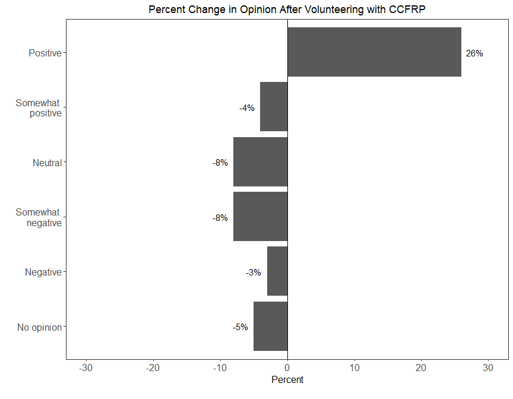

Figure 2. The percent change in survey respondents’ opinion of California MPAs after volunteering with the California Collaborative Fisheries Research Program (CCFRP), relative to before volunteering with CCFRP (n = 228). There were increases in positive opinions of California MPA’s after involvement with CCFRP, relative to before involvement with CCFRP. All other opinion changes were negative.

### 10 & 12

**Before and After** volunteering with CCFRP, did you believe the creation of MPAs would affect the size/abundance of groundfish inside MPAs?

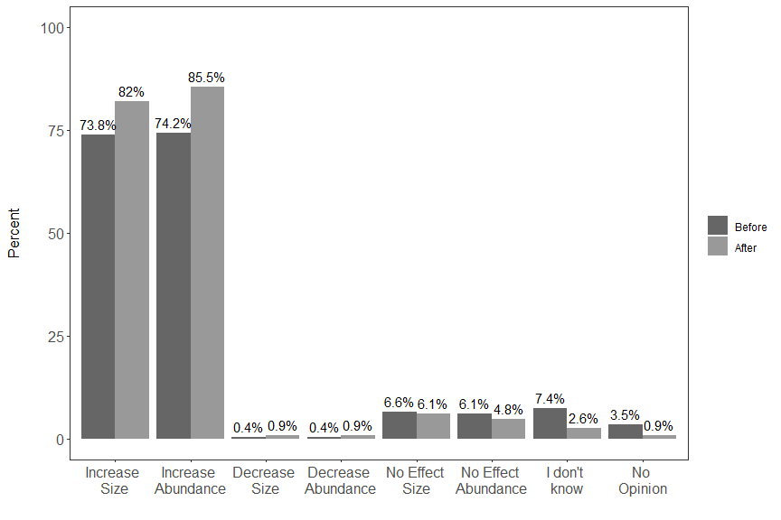

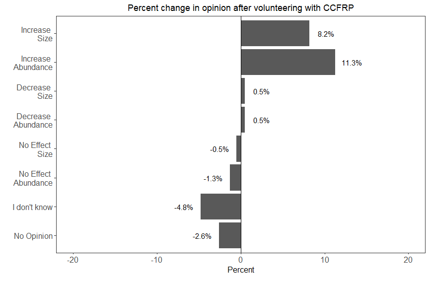

### 13

If you believe that California MPA creation affected **groundfish abundance and/or size**, what aspect(s) of MPAs do you believe caused these changes?

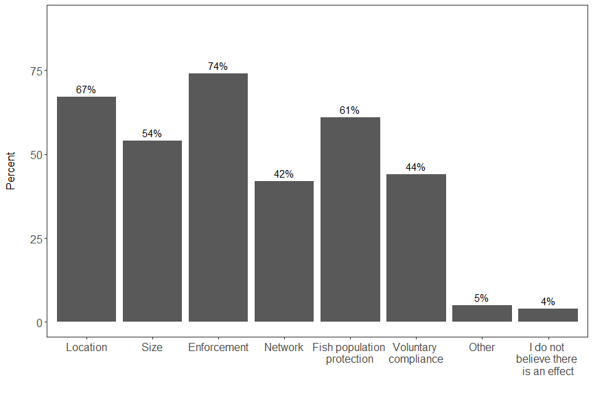

### 14

In your **opinion**, what is the purpose of a Marine Protected Area?

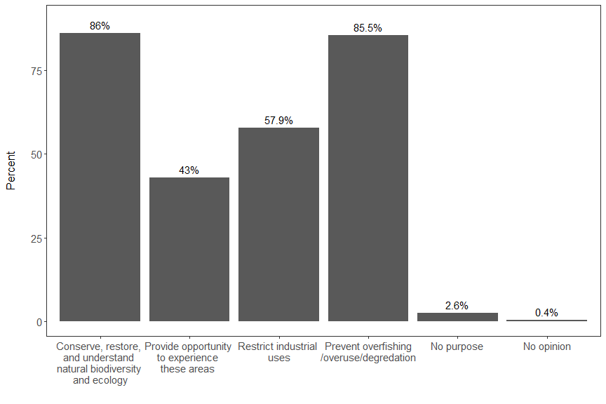

### 15

Have you ever fished in a Marine Protected Area before it was protected **OR** while volunteering with CCFRP? (If no, skip to section 3)

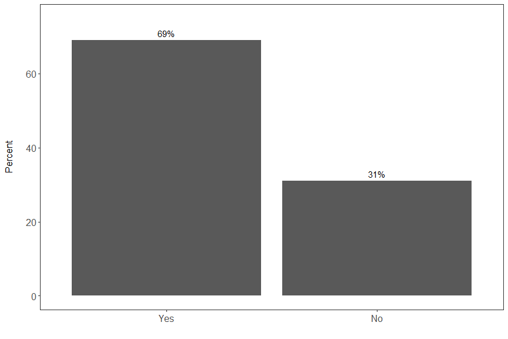

### 16

Think about this when answering a-c: Have you experienced a difference in fishing in an MPA versus outside of an MPA?

1. I catch more fish when fishing inside…
2. I catch a greater diversity of fish species when fishing inside…
3. I catch larger fish when I fish inside…

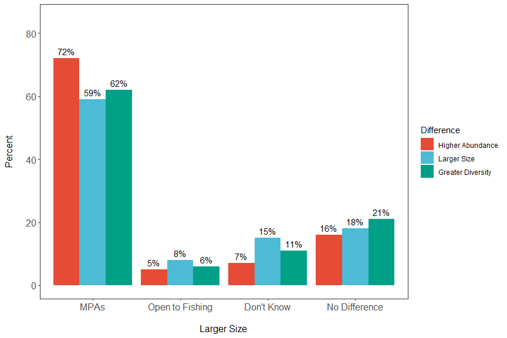

### 17

What is the **primary** reason you enjoy fishing with CCFRP in an MPA?

> **62%** of CCFRP volunteer fishers say that collecting scientific fishing data is the *primary* reason they enjoy fishing with CCFRP in MPAs.

### 18

Hypothetically, how much would you be willing to pay for one day of catch and release fishing inside an MPA while **NOT** participating on a CCFRP trip?

> **1/3** of CCFRP volunteer fishers would pay between *$50 and $500* for a day of catch-and-release fishing in an MPA.

## Section 3) Natural Resource Conservation

### 19

In general, would you say you are more conservation-minded or less conservation-minded than others in the recreational angling community?

Compared to the rest of the angling community, I am…

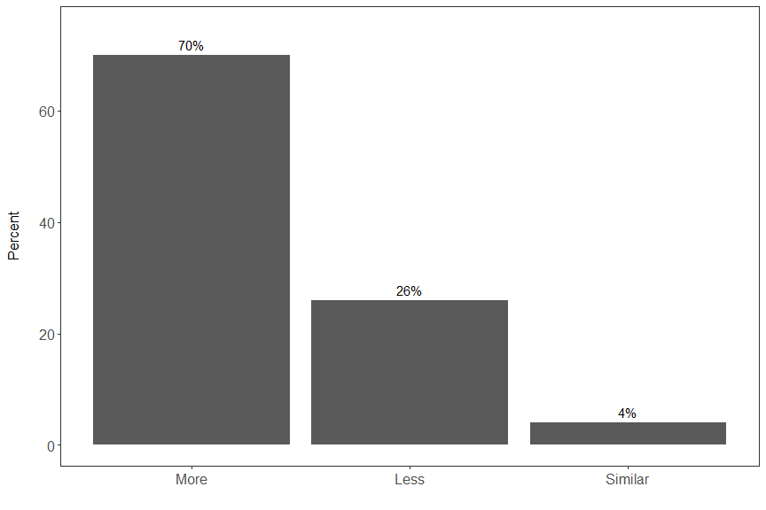

### 20

Do you participate in activities with conservation-oriented groups (separate from CCFRP)?

> **55%** of CCFRP volunteer fishers participate in activities with other conservation-oriented groups; **45%** of CCFRP volunteer fishers do not.

### 21

How informed do you consider yourself to be concerning ocean issues in California?

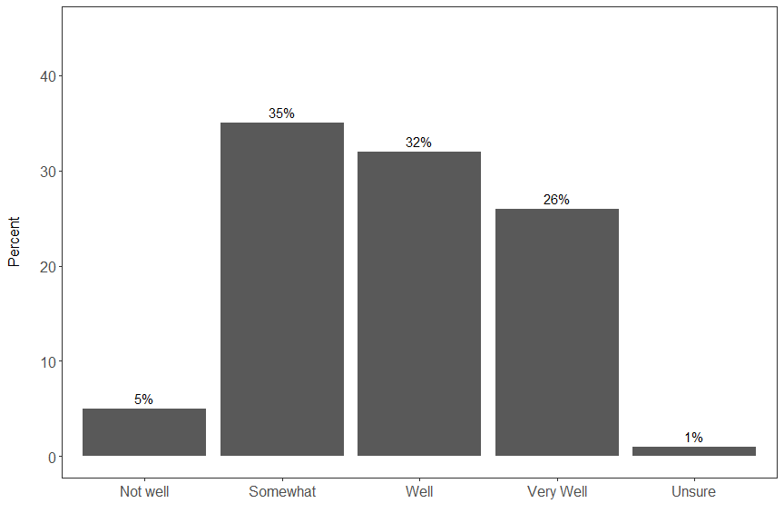

### 22

In what ways do you currently obtain information about ocean related issues? Select all that apply.

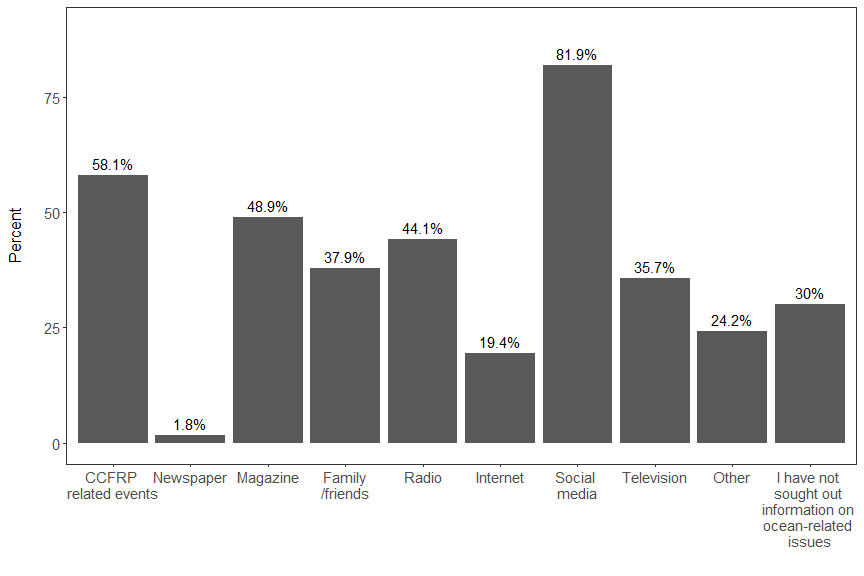

### 23

In your opinion, how well are California groundfish stocks managed?

I believe California groundfish stocks are:

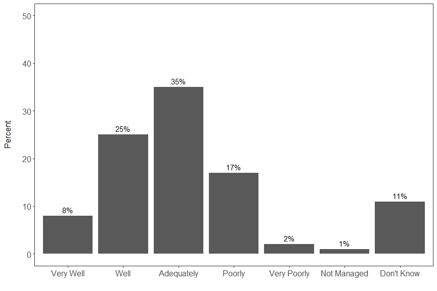

### 24

Please rank the following types of fishing gear or fishing practices(from 1 to 8) as having the greatest impact on the degradation of the marine environment or reduction in fish stocks. (1 is least impact and 8 is greatest impact).

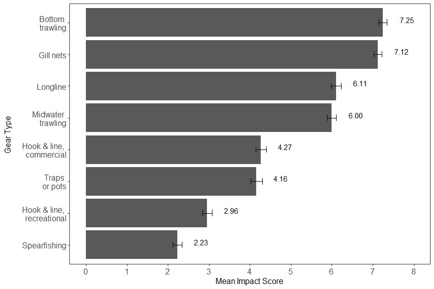

### 25

This question consists of a chart that queries you on your opinion of potential ocean issues. Statements are rated 1-7. An answer of ‘1’ indicates that you strongly disagree, ‘4’ indicates no opinion, and ‘7’ indicates you strongly agree with the statement.

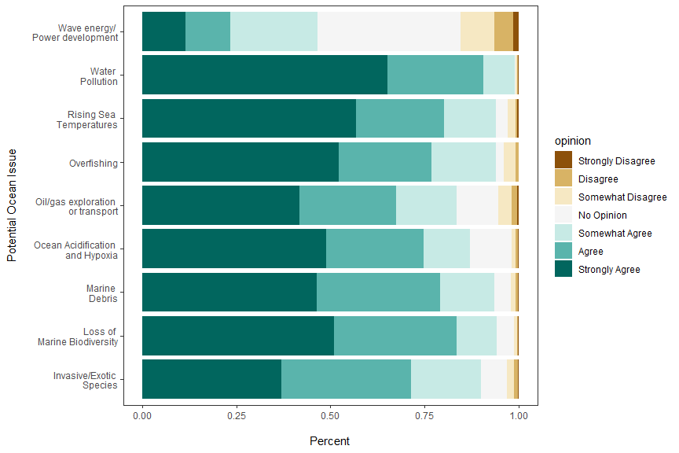

### 26

How interconnected are you with nature? (1 - 7, where 1 is completely separated and 7 is completely interconnected)

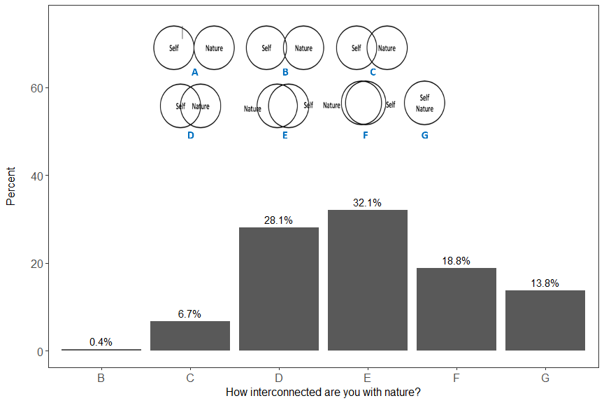